# Practica 2: Manejo de datos en R

Analisis descriptivo de datos

Emmanuel Garduño Téllez

Estadistica Comutacional

#personalizar nuestra seccion

```r
options(digits=3,papersize = "letter")
# https://stat.ethz.ch/R-manual/R-devel/library/base/html/options.html


# Opciones globales en graficas
par(mar=c(5.1,5,4.1,2.1),font=3,family="sans",bg="yellow")
```

```r
setwd("C:/Users/Emman/Documents/CCH-N} FES-A/fessaa/FES/7mo semestre/Temas Selectos de Estadistica")
library(readr)
diabetes <- read_csv("./DATA/diabetes.csv",
    locale = locale(decimal_mark = ","))
```

# 1 [15 puntos] Descripción de las variables

## 1.1 Indica el tipo de variable (cualitativa/cuantitativa–discreta o continua). Indica la escala de medición (nominal/ordinal/intervalo/razón) de cada variable.

| Variable | Tipo | Escala de medición |
| --- | --- | --- |
| patient_number | cuantitativa/discreta | intervalo |
| cholesterol | cuantitativa/discreta | intervalo |
| glucose | cuantitativa/discreta | razon |
| hdl_chol | cuantitativa/discreta | intervalo |
| chol_hdl_ratio | cuantitativa/continua | razon |
| age | cuantitativa/discreta | razon |
| gender | cualitativa | nominal |
| height | cuantitativa/discreta | intervalo |
| weight | cuantitativa/discreta | intervalo |
| bmi | cuantitativa/continua | intervalo |
| systolic_bp | cuantitativa/discreta | intervalo |
| diastolic_bp | cuantitativa/discreta | intervalo |
| waist | cuantitativa/discreta | intervalo |
| hip | cuantitativa/discreta | intervalo |
| waist_hip_ratio | cuantitativa/continua | intervalo |
| diabetes | cualitativa | nominal |

# 2 [20 puntos] Análisis descriptivo de variables cualitativas

## 2.1 Elige una variable de este tipo y realiza una tabla de frecuencias que contenga frecuencias absolutas, frecuencias relativas y sus respectivas acumuladas; además de los totales. Interpreta los resultados en el contexto de tu problema.

La variable va a ser gender, que contiene informacion del genero de las personas con diabetes

```r
#Tabla de frecuencia absolutas
tabla_genero <- table(diabetes$gender)
print(tabla_genero)
```

```
##
## female   male
##    228    162
```

```r
sum(tabla_genero)
```

```
## [1] 390
```

```r
nrow(diabetes)
```

```
## [1] 390
```

```r
#frecuencias relativas
prop_genero <- round(prop.table(tabla_genero),digits = 3)
print(prop_genero)
```

```
##
## female   male
##  0.585  0.415
```

```r
sum(prop_genero)
```

```
## [1] 1
```

Como podemos ver, no existen valor con N/A, y que hay mas mujeres en este estudio, siendo un total de 228 mujeres y 162 hombres

## 2.2 Realiza el análisis gráfico adecuado para esta variable (la gráfica debe incluir títulos y color). Interpreta los resultados.

En este caso para el analisis grafico, usare diagrama de barras

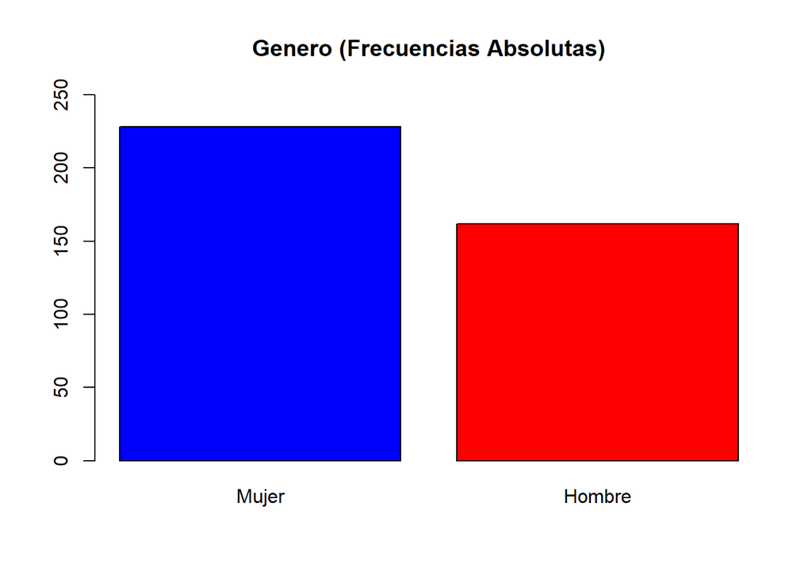

```r
barplot(tabla_genero,names.arg=c("Mujer","Hombre"),col=c("blue","red"), ylim=c(0,250))
 title("Genero (Frecuencias Absolutas)")
```

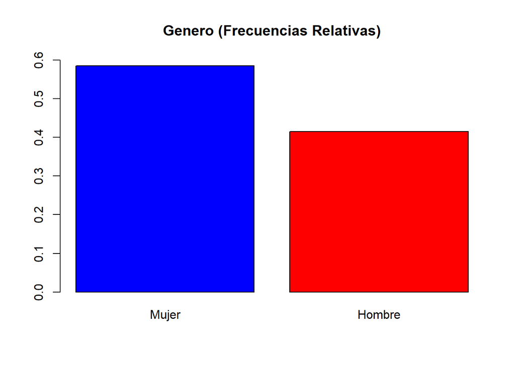

```r
barplot(prop_genero,names.arg=c("Mujer","Hombre"),col=c("blue","red"),,ylim=c(0,0.6))
 title("Genero (Frecuencias Relativas)")
```

De la gráfica de barras se observa que, hay diferencias entre el número de mujeres y hombres, en donde se realizo la toma de datos. Vale la pena analizar estadísticamente si esto es así:

```r
# Comparacion entre la proporcion de mujeres y la proporcion de hombres.

n_muj<- tabla_genero[1] #mujeres
n_hom<- tabla_genero[2] #hombres

prop.test(x=c(n_muj, n_hom), n=c(390,390), conf.level=0.90)
```

```
##
##  2-sample test for equality of proportions with continuity correction
##
## data:  c(n_muj, n_hom) out of c(390, 390)
## X-squared = 22, df = 1, p-value = 3e-06
## alternative hypothesis: two.sided
## 90 percent confidence interval:
##  0.109 0.230
## sample estimates:
## prop 1 prop 2
##  0.585  0.415
```

De acuerdo con el intervalo de confianza para la diferencia de proporciones se concluye que SÍ hay diferencia entre el número de mujeres y hombres, de hecho $p_{hombre}-p_{mujer}<0$; así que la proporción de mujeres si es estadísticamente mayor a la correspondiente de los hombres (como lo muestran las gráficas).

## 2.3 Elabora una tabla de los estadísticos de resumen que son aplicables a esta variable.

En este caso solo puede obtenerse la **moda**

```r
library(modeest)
# Variable nominal
mfv(diabetes$gender)     # moda
```

```
## [1] "female"
```

```r
mode(diabetes$gender)    # NO!
```

```
## [1] "character"
```

```r
summary(diabetes$gender)   # no tiene interpretacion
```

```
##    Length     Class      Mode
##       390 character character
```